# Actividad 2 - Problema 2

Juan José Restrepo Rosero

2024-08-14

# **Problema 2 - Propiedades de los estimadores**

La simulación ayuda a entender y validad las propiedades de los estimadores estadísticos como son: insesgadez, eficiencia y la consistencia principalmente. El siguiente problema permite evidenciar las principales características de un grupo de estimadores propuestos para la estimación de un parámetro asociado a un modelo de probabilidad.

Sean X1, X2, X3 y X4, una muestra aleatoria de tamaño n=4 cuya población la conforma una distribución exponencial con parámetro θ desconocido. Determine las características de cada uno de los siguientes estimadores propuestos:

$$\hat{\theta}_1=[\frac{(X_1+X_2)}{6}+\frac{(X_3+X_4)}{3}]$$
$$\hat{\theta}_2=[\frac{(X_1+2X_2+3X_3+4X_4)}{5}]$$

$$\hat{\theta}_3=[\frac{(X_1+X_2+X_3+X_4)}{4}]$$

$$\hat{\theta}_4=[\frac{\min(X_1+X_2+X_3+X_4)+\max(X_1+X_2+X_3+X_4)}{2}]$$

1. Genere una muestras de n = 20, 50, 100 y 1000 para cada uno de los estimadores planteados.
2. En cada caso evalue las propiedades de insesgadez, eficiencia y consistencia
3. Suponga un valor para el parámetro θ

**Resultados**

## **Para n=20**

1. Se generó una muestra de n=20 para cada uno de los estimadores. Esta presentó el sesgo, varianza y gráfico boxplot con la comparación de los estiamdores:

```
## [1] -0.7237420  1.5287549 -0.3899028 -1.0546582
```

```
## [1] 0.5739868 3.9649782 0.6894771 0.1098417
```

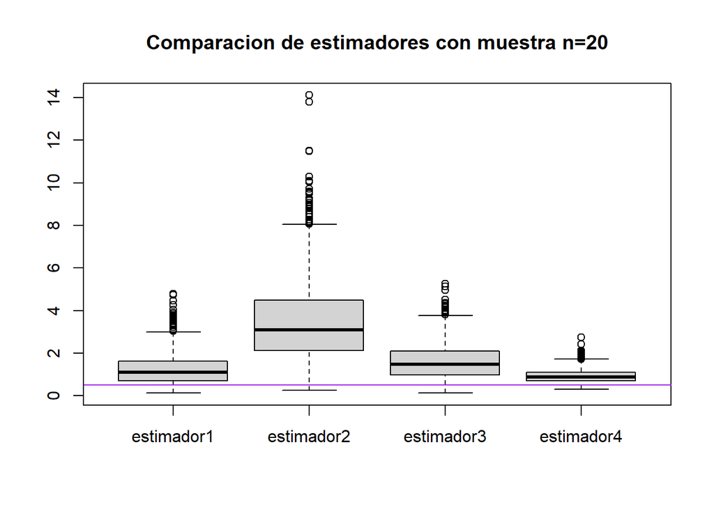

## **Para n=50**

```
## [1] -0.7297860  1.3136783 -0.3912028 -0.8740601
```

```
## [1] 0.5225037 3.5999041 0.7791690 0.1040561
```

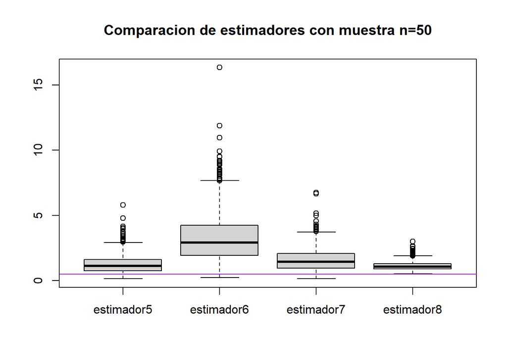

## **Para n=100**

```
## [1] -0.7500381  1.2846360 -0.4032421 -0.7064916
```

```
## [1] 0.5261362 3.2600849 0.7360324 0.1017584
```

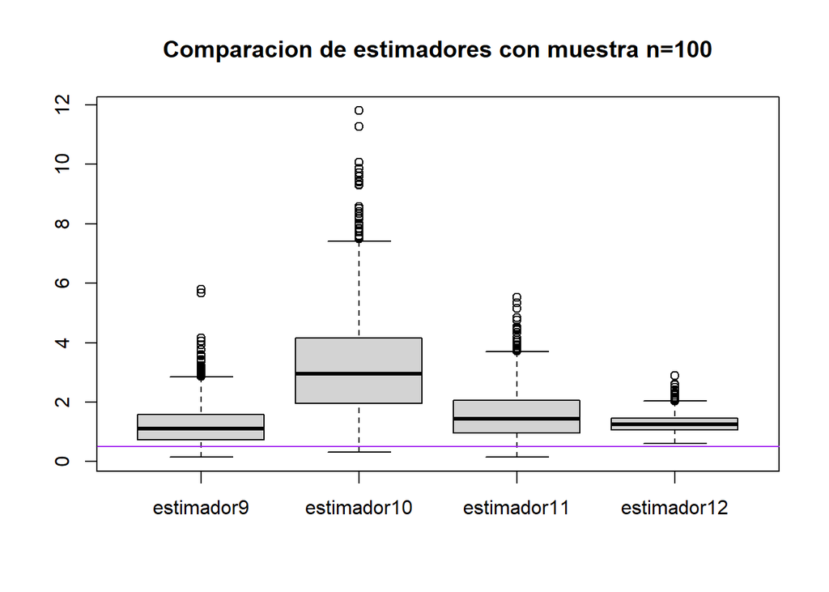

## **Para n=1000**

```
## [1] -0.7698063  1.3283487 -0.3932957 -0.1512081
```

```
## [1] 0.46460223 3.53383111 0.76468838 0.09337634
```

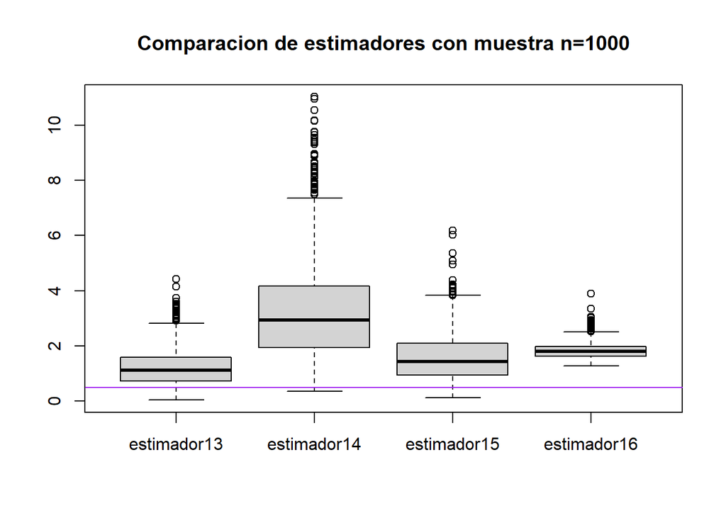